# DSCI460 Final Report

Colton Beck

4/26/2022

# Background

I am planning a trip to San Diego on a quest to find what makes a good San Diego burrito . . . great! It has been one of my dreams to experience authentic Mexican food and who doesn’t love a good burrito right? So before boarding the plane, I download this data set from https://kaggle.com to do research on what makes a good burrito . . . great!

Data set link: https://www.kaggle.com/datasets/srcole/burritos-in-san-diego

Data set description: Mexican cuisine is often the best food option is southern California. And the burrito is the hallmark of delicious taco shop food: tasty, cheap, and filling. Appropriately, an effort was launched to critique burritos across the county and make this data open to the lay burrito consumer. At this time, the data set contains ratings from over 200 burritos from around 50 restaurants.

- There are 10 core dimensions of the San Diego burrito.
  - Volume
  - Tortilla quality
  - Temperature
  - Meat quality
  - Non-meat filling quality
  - Meat-to-filling ratio
  - Uniformity
  - Salsa quality
  - Flavor synergy
  - Wrap integrity

All of these measures (except for Volume) are rated on a scale from 0 to 5, 0 being terrible, and 5 being optimal. Other information available for each burrito includes an overall rating, cost, Yelp rating of the restaurant, and more.

Also the data set has an ingredient list . . .

To view more information check out this link here https://srcole.github.io/100burritos/

# Loading Data Set

```r
filename <- here("burritos.csv")
burrito <-  read_csv(file = filename, col_names = TRUE)
```

```
## * Salsa -> Salsa...23
## * Salsa -> Salsa...50
```

# Cleaning

```r
burrito %>%
  filter(!is.na(Cost), !is.na(overall), !is.na(Temp), !is.na(Meat), !is.na(`Meat:filling`), !is.na(Fillings), !is.na(Uniformity), !is.na(Salsa...23), !is.na(Synergy), !is.na(Wrap)) %>%
  mutate(
    Beef = ifelse(is.na(Beef), 0, 1),
    Pico = ifelse(is.na(Pico), 0, 1),
    Guac = ifelse(is.na(Guac), 0, 1),
    Cheese = ifelse(is.na(Cheese), 0, 1),
    Fries = ifelse(is.na(Fries), 0, 1),
    `Sour cream` = ifelse(is.na(`Sour cream`), 0, 1),
    Pork = ifelse(is.na(Pork), 0, 1),
    Chicken = ifelse(is.na(Chicken), 0, 1),
    Shrimp = ifelse(is.na(Shrimp), 0, 1),
    Fish = ifelse(is.na(Fish), 0, 1),
    Rice = ifelse(is.na(Rice), 0, 1),
    Beans = ifelse(is.na(Beans), 0, 1),
    Lettuce = ifelse(is.na(Lettuce), 0, 1),
    Tomato = ifelse(is.na(Tomato), 0, 1),
    `Bell peper` = ifelse(is.na(`Bell peper`), 0, 1),
    Carrots = ifelse(is.na(Carrots), 0, 1),
    Cabbage = ifelse(is.na(Cabbage), 0, 1),
    Sauce = ifelse(is.na(Sauce), 0, 1),
    SalsaRating = ifelse(is.na(Salsa...23), 0, Salsa...23),
    Cilantro = ifelse(is.na(Cilantro), 0, 1),
    Onion = ifelse(is.na(Onion), 0, 1),
    Taquito = ifelse(is.na(Taquito), 0, 1),
    Pineapple = ifelse(is.na(Pineapple), 0, 1),
    Ham = ifelse(is.na(Ham), 0, 1),
    `Chile relleno` = ifelse(is.na(`Chile relleno`), 0, 1),
    Nopales = ifelse(is.na(Nopales), 0, 1),
    Lobster = ifelse(is.na(Lobster), 0, 1),
    Queso = ifelse(is.na(Queso), 0, 1),
    Egg = ifelse(is.na(Egg), 0, 1),
    Mushroom = ifelse(is.na(Mushroom), 0, 1),
    Bacon = ifelse(is.na(Bacon), 0, 1),
    Sushi = ifelse(is.na(Sushi), 0, 1),
    Avocado = ifelse(is.na(Avocado), 0, 1),
    Corn = ifelse(is.na(Corn), 0, 1),
    Zucchini = ifelse(is.na(Zucchini), 0, 1),
    SalsaIngred = ifelse(is.na(Salsa...50), 0, 1)
    ) %>%
     select(-Salsa...50, -Salsa...23)-> clean_plate
```

# Exploratory Data Analysis

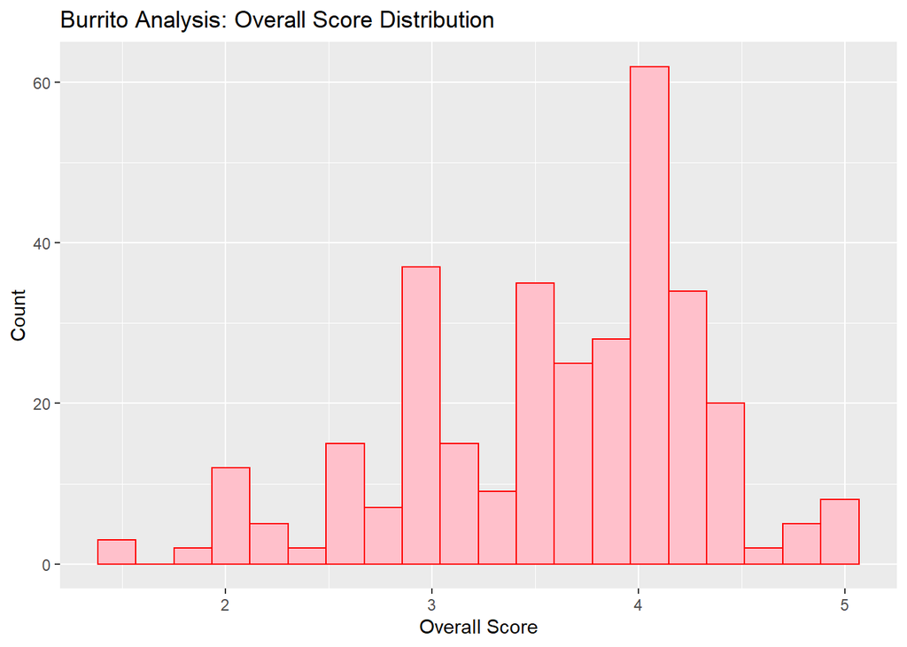

```r
clean_plate %>%
  ggplot(aes(x = overall)) + geom_histogram(bins = 20, fill =  "pink", color = "red") + labs(title = "Burrito Analysis: Overall Score Distribution") + xlab("Overall Score") + ylab("Count")
```

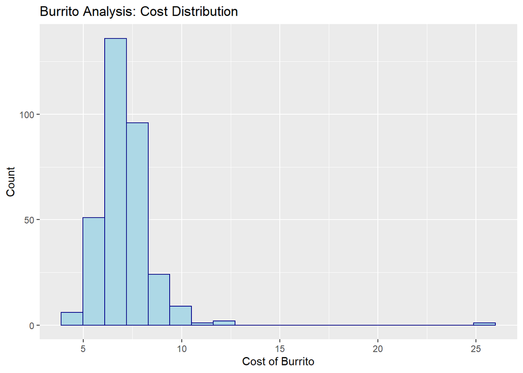

```r
clean_plate %>%
  ggplot(aes(x = Cost)) + geom_histogram(bins = 20, fill =  "lightblue", color = "darkblue") + labs(title = "Burrito Analysis: Cost Distribution") + xlab("Cost of Burrito") + ylab("Count")
```

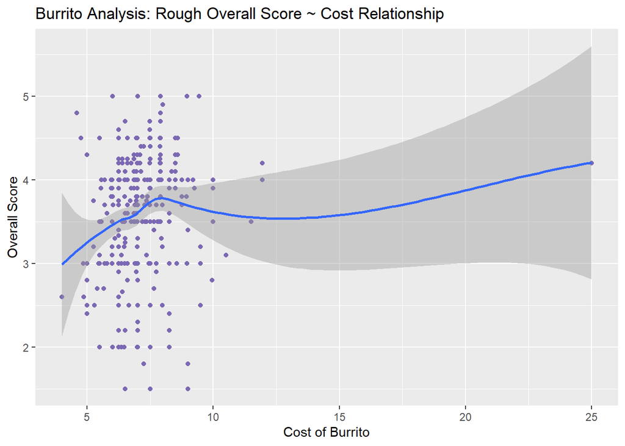

```r
clean_plate %>%
  ggplot(aes(x = Cost, y = overall)) + geom_point(color = "#7c69b3") + geom_smooth() + labs(title = "Burrito Analysis: Rough Overall Score ~ Cost Relationship") + ylab("Overall Score") + xlab("Cost of Burrito")
```

```r
clean_plate %>%
  summarise(
    avgCost = mean(Cost),
    avgScore = mean(overall)
  )
```

```
## # A tibble: 1 x 2
##   avgCost avgScore
##     <dbl>    <dbl>
## 1    7.12     3.59
```

Looking at the following variables like Tortilla, Temp, Meat, Fillings that are not meat, Fillings that are meat, Uniformity, Salsa quality, Flavor synergy, Wrap integrity the graphs all look very similar because they are scoring on values of 0.0 to 5.0. Zero meaning “terrible” and 5 being consider “optimal”. So lets take a quick peak here, at the reviewer scores . . .

When planning my trip to find the best burrito in the City of San Diego, I had to ask myself the question. What makes a good burrito a great burrito? I am no certified burrito expert, I’m just an aspiring Data Scientist. I started my search for that answer with the Meat Filling Field. . .

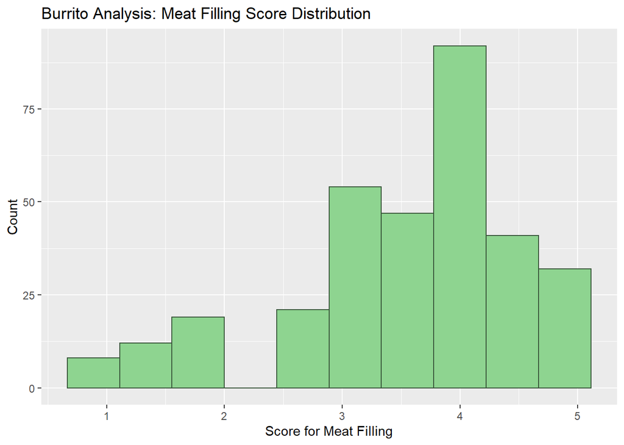

```r
clean_plate %>%
  ggplot(aes(x = `Meat:filling`)) + geom_histogram(bins = 10, color = "#385439", fill = "#8ed490" ) + labs(title = "Burrito Analysis: Meat Filling Score Distribution") + xlab("Score for Meat Filling") + ylab("Count")
```

Taking a look at this histogram we see that there is a good number of restaurants that got reported well on there Meat Filling. That’s good to hear I have been carving some carne burritos. I wonder how the filling that is meat impacts the score . . .

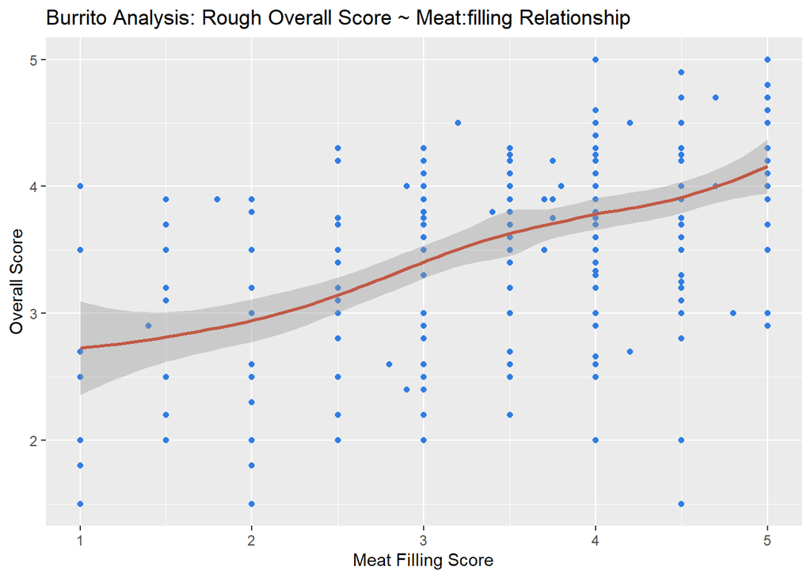

```r
clean_plate %>%
  ggplot(aes(x = `Meat:filling`, y = overall)) + geom_point(color = "#307de3") + geom_smooth(color = "#c25946") + labs(title = "Burrito Analysis: Rough Overall Score ~ Meat:filling Relationship") + ylab("Overall Score") + xlab("Meat Filling Score")
```

Taking a look at the relationship it seems that Meat filling actually makes a good burrito! There does seem to be a positive relationship but I do not think it is strong enough to be used by itself in a model.

Since we know that meat filling postive correlates with the overall score of a burrito, I decided that maybe the quality of the meat might also by a part in the score!

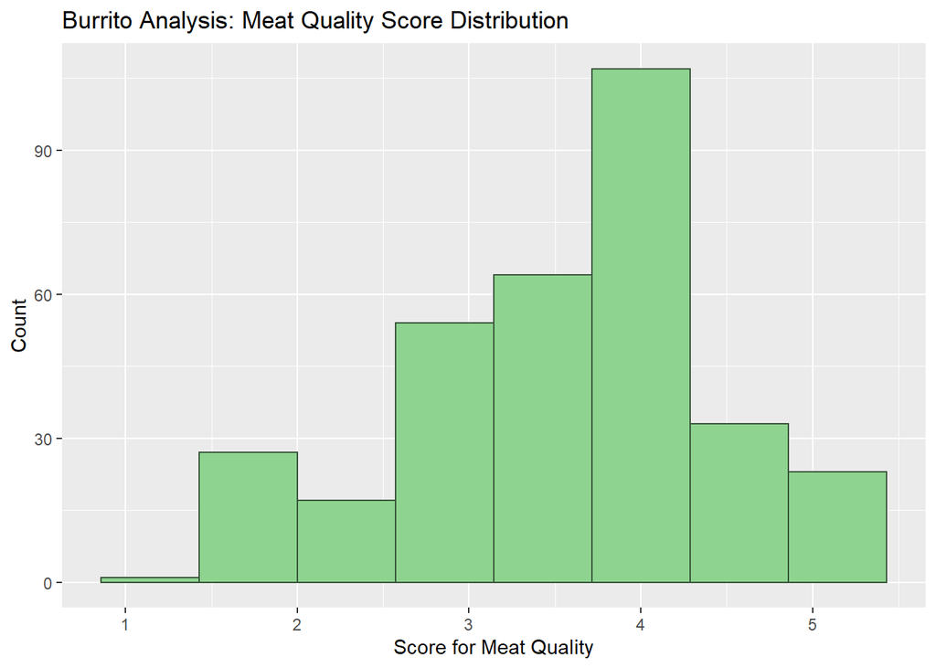

```r
clean_plate %>%
  ggplot(aes(x = Meat)) + geom_histogram(bins = 8, color = "#385439", fill = "#8ed490" ) + labs(title = "Burrito Analysis: Meat Quality Score Distribution") + xlab("Score for Meat Quality") + ylab("Count")
```

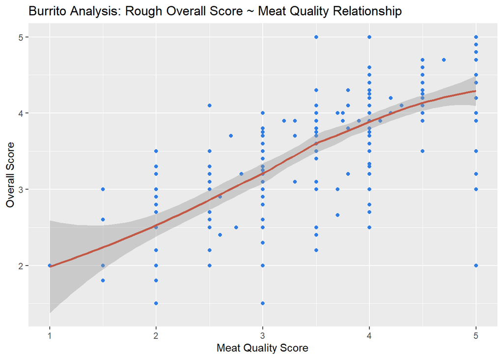

```r
clean_plate %>%
  ggplot(aes(x = Meat, y = overall)) + geom_point(color = "#307de3") + geom_smooth(color = "#c25946") + labs(title = "Burrito Analysis: Rough Overall Score ~ Meat Quality Relationship") + ylab("Overall Score") + xlab("Meat Quality Score")
```

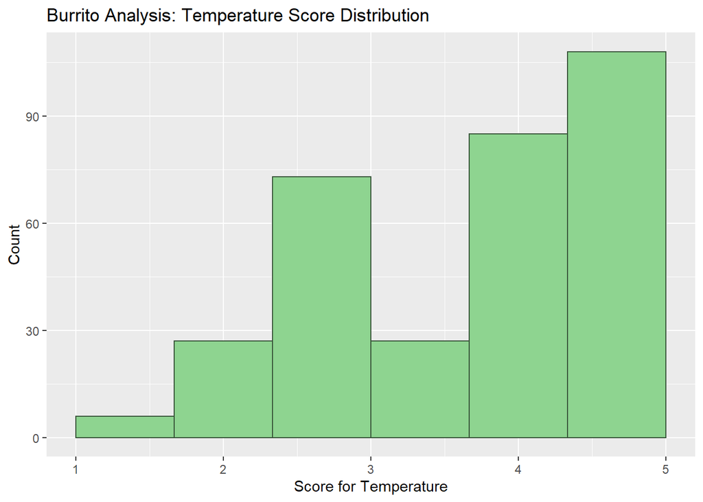

```r
clean_plate %>%
  ggplot(aes(x = Temp)) + geom_histogram(bins = 7, color = "#385439", fill = "#8ed490" ) + labs(title = "Burrito Analysis: Temperature Score Distribution") + xlab("Score for Temperature") + ylab("Count")
```

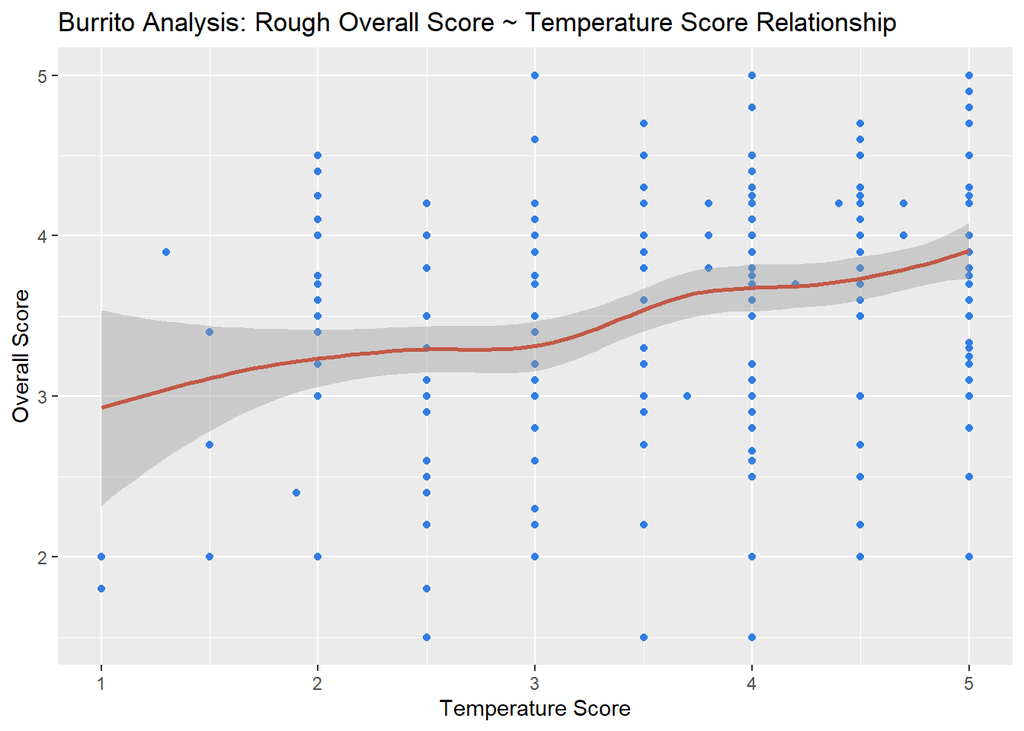

```r
clean_plate %>%
  ggplot(aes(x = Temp, y = overall)) + geom_point(color = "#307de3") + geom_smooth(color = "#c25946") + labs(title = "Burrito Analysis: Rough Overall Score ~ Temperature Score Relationship") + ylab("Overall Score") + xlab("Temperature Score")
```

Me personally I like my tortilla pressed when I’m ordering a burrito. It’s looks like San Diego though is indifferent about this though. I do not know though if temp is a good predictor, but we do see a slight positive correlation here.

Lastly I’m going to take a look at Uniformity just because I do not exactly what this variable is . . . but they said that it was vital to scoring

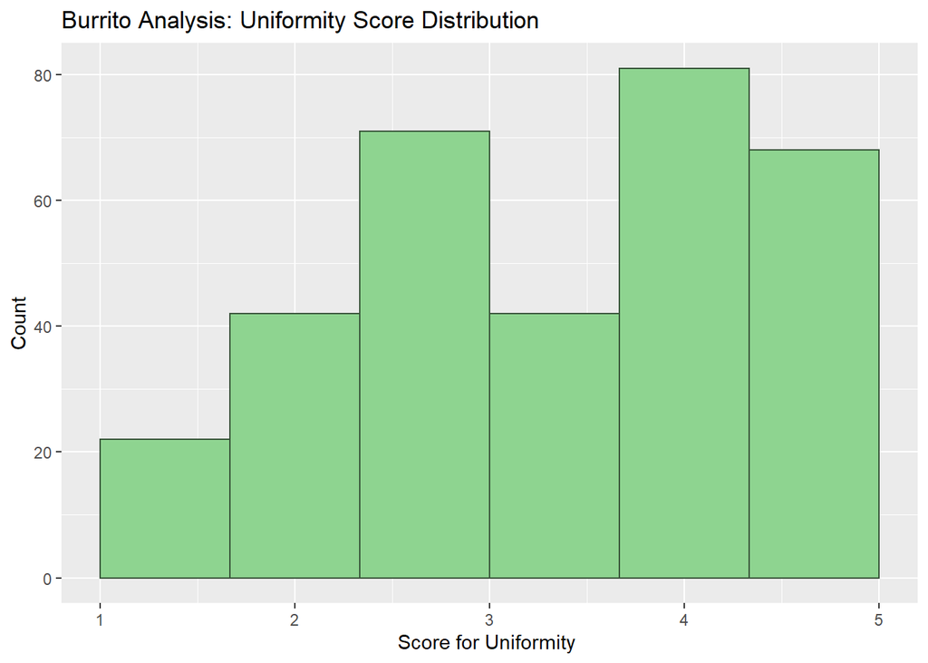

```r
clean_plate %>%
  ggplot(aes(x = Uniformity)) + geom_histogram(bins = 7, color = "#385439", fill = "#8ed490" ) + labs(title = "Burrito Analysis: Uniformity Score Distribution") + xlab("Score for Uniformity ") + ylab("Count")
```

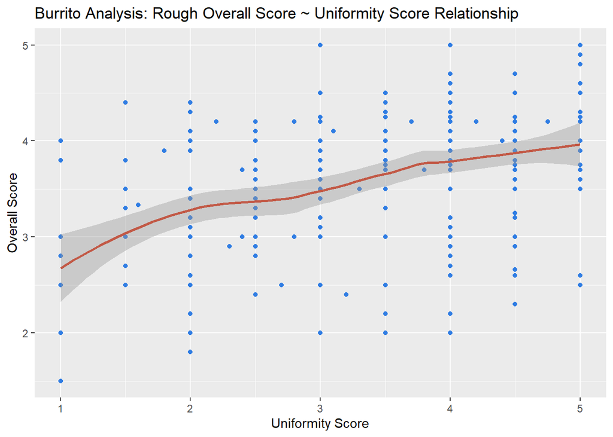

```r
clean_plate %>%
  ggplot(aes(x = Uniformity, y = overall)) + geom_point(color = "#307de3") + geom_smooth(color = "#c25946") + labs(title = "Burrito Analysis: Rough Overall Score ~ Uniformity Score Relationship") + ylab("Overall Score") + xlab("Uniformity Score")
```

Looks like a neat / uniform burrito positive correlates the overall score.

# Model Building

```r
set.seed(123)
whats_your_order <- initial_split(clean_plate)
burrito_train <- training(whats_your_order)
leftovers <- testing(whats_your_order)
```

```r
burrito_reg <- linear_reg(mode = "regression") %>%
  set_engine("lm")

review_rec <- recipe(overall ~ Tortilla + Temp + Meat + Fillings + `Meat:filling` + Uniformity + SalsaRating + Synergy + Wrap, data = burrito_train)

hopefully_a_good_burrito <- workflow() %>%
  add_model(burrito_reg) %>%
  add_recipe(review_rec)

hopefully_a_good_burrito %>%
  fit(burrito_train)
```

```
## == Workflow [trained] ==========================================================
## Preprocessor: Recipe
## Model: linear_reg()
##
## -- Preprocessor ----------------------------------------------------------------
## 0 Recipe Steps
##
## -- Model -----------------------------------------------------------------------
##
## Call:
## stats::lm(formula = ..y ~ ., data = data)
##
## Coefficients:
##    (Intercept)        Tortilla            Temp            Meat        Fillings
##       0.006439        0.010248        0.047436        0.201338        0.248796
## `Meat:filling`      Uniformity     SalsaRating         Synergy            Wrap
##       0.094796        0.046625        0.035324        0.285736        0.038576
```

```r
summary(hopefully_a_good_burrito %>% fit(burrito_train) %>% extract_fit_engine())
```

```
##
## Call:
## stats::lm(formula = ..y ~ ., data = data)
##
## Residuals:
##     Min      1Q  Median      3Q     Max
## -1.3596 -0.1726  0.0160  0.1695  1.2177
##
## Coefficients:
##                Estimate Std. Error t value Pr(>|t|)
## (Intercept)    0.006439   0.140422   0.046 0.963465
## Tortilla       0.010248   0.031150   0.329 0.742467
## Temp           0.047436   0.022443   2.114 0.035609 *
## Meat           0.201338   0.034370   5.858 1.58e-08 ***
## Fillings       0.248796   0.036650   6.788 9.24e-11 ***
## `Meat:filling` 0.094796   0.025178   3.765 0.000211 ***
## Uniformity     0.046625   0.022284   2.092 0.037491 *
## SalsaRating    0.035324   0.026523   1.332 0.184224
## Synergy        0.285736   0.038339   7.453 1.76e-12 ***
## Wrap           0.038576   0.018908   2.040 0.042461 *
## ---
## Signif. codes:  0 '***' 0.001 '**' 0.01 '*' 0.05 '.' 0.1 ' ' 1
##
## Residual standard error: 0.3157 on 234 degrees of freedom
## Multiple R-squared:  0.8029, Adjusted R-squared:  0.7953
## F-statistic: 105.9 on 9 and 234 DF,  p-value: < 2.2e-16
```

This shows us a linear regression model of rating variables

What about ingredient list?

Model a linear regression for ingredients

```r
burrito_reg <- linear_reg(mode = "regression") %>%
  set_engine("lm")

ingred_rec <- recipe(overall ~ Beef + Pico + Guac + Cheese + Fries + `Sour cream` + Pork + Chicken + Shrimp + Fish + Rice +
                          Beans + Lettuce + Tomato + `Bell peper` + Carrots + Cabbage + Sauce + SalsaIngred + Cilantro +
                          Onion + Taquito + Pineapple + Ham  + `Chile relleno` + Nopales + Lobster + Queso + Egg + Mushroom +
                          Bacon + Sushi + Avocado + Corn + Zucchini,  data = burrito_train)

hopefully_a_good_burrito <- workflow() %>%
  add_model(burrito_reg) %>%
  add_recipe(ingred_rec)

hopefully_a_good_burrito %>%
  fit(burrito_train)
```

```
## == Workflow [trained] ==========================================================
## Preprocessor: Recipe
## Model: linear_reg()
##
## -- Preprocessor ----------------------------------------------------------------
## 0 Recipe Steps
##
## -- Model -----------------------------------------------------------------------
##
## Call:
## stats::lm(formula = ..y ~ ., data = data)
##
## Coefficients:
##     (Intercept)             Beef             Pico             Guac
##         3.78564         -0.50912         -0.02504          0.18401
##          Cheese            Fries     `Sour cream`             Pork
##         0.30473         -0.05466          0.07464         -0.44130
##         Chicken           Shrimp             Fish             Rice
##        -0.72864         -0.07815         -2.20135         -0.05194
##           Beans          Lettuce           Tomato     `Bell peper`
##        -0.24832         -0.66158          0.58905         -0.83044
##         Carrots          Cabbage            Sauce      SalsaIngred
##         0.03561          0.74266          0.13292         -1.63997
##        Cilantro            Onion          Taquito        Pineapple
##        -0.31775          0.29038          0.02807          0.05479
##             Ham  `Chile relleno`          Nopales          Lobster
##         0.29614          0.61163         -0.19091         -2.05027
##           Queso              Egg         Mushroom            Bacon
##              NA         -0.21885         -0.68717               NA
##           Sushi          Avocado             Corn         Zucchini
##         0.41436         -0.21261          0.93299               NA
```

```r
summary(hopefully_a_good_burrito %>% fit(burrito_train) %>% extract_fit_engine())
```

```
##
## Call:
## stats::lm(formula = ..y ~ ., data = data)
##
## Residuals:
##     Min      1Q  Median      3Q     Max
## -2.0016 -0.3576  0.1144  0.4144  1.3824
##
## Coefficients: (3 not defined because of singularities)
##                 Estimate Std. Error t value Pr(>|t|)
## (Intercept)      3.78564    0.07811  48.464   <2e-16 ***
## Beef            -0.50912    0.21044  -2.419   0.0164 *
## Pico            -0.02504    0.14277  -0.175   0.8609
## Guac             0.18401    0.14398   1.278   0.2026
## Cheese           0.30473    0.20965   1.454   0.1476
## Fries           -0.05466    0.20199  -0.271   0.7870
## `Sour cream`     0.07464    0.15113   0.494   0.6219
## Pork            -0.44130    0.22492  -1.962   0.0511 .
## Chicken         -0.72864    0.28455  -2.561   0.0111 *
## Shrimp          -0.07815    0.33780  -0.231   0.8173
## Fish            -2.20135    1.22797  -1.793   0.0745 .
## Rice            -0.05194    0.23526  -0.221   0.8255
## Beans           -0.24832    0.24345  -1.020   0.3089
## Lettuce         -0.66158    0.54971  -1.204   0.2301
## Tomato           0.58905    0.68203   0.864   0.3888
## `Bell peper`    -0.83044    0.78051  -1.064   0.2886
## Carrots          0.03561    0.78007   0.046   0.9636
## Cabbage          0.74266    0.76372   0.972   0.3320
## Sauce            0.13292    0.25725   0.517   0.6059
## SalsaIngred     -1.63997    0.74141  -2.212   0.0280 *
## Cilantro        -0.31775    0.95316  -0.333   0.7392
## Onion            0.29038    0.91065   0.319   0.7501
## Taquito          0.02807    0.43010   0.065   0.9480
## Pineapple        0.05479    0.36127   0.152   0.8796
## Ham              0.29614    0.79250   0.374   0.7090
## `Chile relleno`  0.61163    0.46959   1.302   0.1942
## Nopales         -0.19091    0.52775  -0.362   0.7179
## Lobster         -2.05027    1.30892  -1.566   0.1188
## Queso                 NA         NA      NA       NA
## Egg             -0.21885    0.54304  -0.403   0.6873
## Mushroom        -0.68717    0.72778  -0.944   0.3461
## Bacon                 NA         NA      NA       NA
## Sushi            0.41436    0.68606   0.604   0.5465
## Avocado         -0.21261    0.44482  -0.478   0.6332
## Corn             0.93299    1.09996   0.848   0.3973
## Zucchini              NA         NA      NA       NA
## ---
## Signif. codes:  0 '***' 0.001 '**' 0.01 '*' 0.05 '.' 0.1 ' ' 1
##
## Residual standard error: 0.6816 on 211 degrees of freedom
## Multiple R-squared:  0.1715, Adjusted R-squared:  0.04581
## F-statistic: 1.365 on 32 and 211 DF,  p-value: 0.1028
```

Lets combine those predictors with our model for the reviews

```r
burrito_reg <- linear_reg(mode = "regression") %>%
  set_engine("lm")

review_rec <- recipe(overall ~ Tortilla + Temp + Meat + Fillings + `Meat:filling` + Uniformity + SalsaRating + Synergy + Wrap, data = burrito_train)

combinded_rec <- recipe(overall ~ Tortilla + Temp + Meat + Fillings + `Meat:filling` + Uniformity + SalsaRating + Synergy + Wrap + Beef + Pico + Pork + Chicken + Beans, data = burrito_train)

hopefully_a_good_burrito <- workflow() %>%
  add_model(burrito_reg) %>%
  add_recipe(review_rec)

hopefully_a_better_burrito <- workflow() %>%
  add_model(burrito_reg) %>%
  add_recipe(combinded_rec)

hopefully_a_better_burrito %>%
  fit(burrito_train)
```

```
## == Workflow [trained] ==========================================================
## Preprocessor: Recipe
## Model: linear_reg()
##
## -- Preprocessor ----------------------------------------------------------------
## 0 Recipe Steps
##
## -- Model -----------------------------------------------------------------------
##
## Call:
## stats::lm(formula = ..y ~ ., data = data)
##
## Coefficients:
##    (Intercept)        Tortilla            Temp            Meat        Fillings
##       0.101804       -0.001637        0.047953        0.212535        0.265487
## `Meat:filling`      Uniformity     SalsaRating         Synergy            Wrap
##       0.100036        0.044603        0.037461        0.261373        0.026320
##           Beef            Pico            Pork         Chicken           Beans
##       0.057601       -0.093265       -0.037329       -0.282135       -0.116828
```

# Anova Testing

I wanted to decided which linear regression model to use against my test set. I decided to do an anova test on the two review model and the combined model to see if including our ingredients actually produced a better fitting model.

```r
anova(hopefully_a_good_burrito %>% fit(burrito_train) %>% extract_fit_engine(), hopefully_a_better_burrito %>% fit(burrito_train) %>% extract_fit_engine())
```

```
## Analysis of Variance Table
##
## Model 1: ..y ~ Tortilla + Temp + Meat + Fillings + `Meat:filling` + Uniformity +
##     SalsaRating + Synergy + Wrap
## Model 2: ..y ~ Tortilla + Temp + Meat + Fillings + `Meat:filling` + Uniformity +
##     SalsaRating + Synergy + Wrap + Beef + Pico + Pork + Chicken +
##     Beans
##   Res.Df    RSS Df Sum of Sq      F   Pr(>F)
## 1    234 23.325
## 2    229 21.544  5    1.7809 3.7859 0.002586 **
## ---
## Signif. codes:  0 '***' 0.001 '**' 0.01 '*' 0.05 '.' 0.1 ' ' 1
```

Looking at the test, it does show that the ingredient fields are significant and should be included in the model.

```r
summary(hopefully_a_better_burrito %>% fit(burrito_train) %>% extract_fit_engine())
```

```
##
## Call:
## stats::lm(formula = ..y ~ ., data = data)
##
## Residuals:
##      Min       1Q   Median       3Q      Max
## -1.01777 -0.19768  0.00732  0.17100  1.16948
##
## Coefficients:
##                 Estimate Std. Error t value Pr(>|t|)
## (Intercept)     0.101804   0.145176   0.701  0.48386
## Tortilla       -0.001637   0.030556  -0.054  0.95732
## Temp            0.047953   0.022136   2.166  0.03132 *
## Meat            0.212535   0.033960   6.258 1.90e-09 ***
## Fillings        0.265487   0.036077   7.359 3.30e-12 ***
## `Meat:filling`  0.100036   0.024625   4.062 6.67e-05 ***
## Uniformity      0.044603   0.021771   2.049  0.04163 *
## SalsaRating     0.037461   0.026168   1.432  0.15364
## Synergy         0.261373   0.037975   6.883 5.57e-11 ***
## Wrap            0.026320   0.019114   1.377  0.16986
## Beef            0.057601   0.053520   1.076  0.28295
## Pico           -0.093265   0.050024  -1.864  0.06354 .
## Pork           -0.037329   0.071053  -0.525  0.59983
## Chicken        -0.282135   0.094285  -2.992  0.00307 **
## Beans          -0.116828   0.079887  -1.462  0.14500
## ---
## Signif. codes:  0 '***' 0.001 '**' 0.01 '*' 0.05 '.' 0.1 ' ' 1
##
## Residual standard error: 0.3067 on 229 degrees of freedom
## Multiple R-squared:  0.8179, Adjusted R-squared:  0.8068
## F-statistic: 73.47 on 14 and 229 DF,  p-value: < 2.2e-16
```

Adding those predictors did raise our R-squared value lets compare these two models and see if they are actually different

# Random Forest

```r
recipe_rand <- rand_forest(mode = "regression") %>%
     set_engine("ranger", importance = "impurity")

rand_recipe_wf <- workflow() %>%
     add_model(recipe_rand) %>%
     add_recipe(review_rec)

rand_ingred_wf <- workflow() %>%
     add_model(recipe_rand) %>%
     add_recipe(ingred_rec)

rand_combination_wf <- workflow() %>%
     add_model(recipe_rand) %>%
     add_recipe(combinded_rec)
```

## Recipe Random Forest Model

```r
rand_recipe_wf %>%
     fit(burrito_train)
```

```
## == Workflow [trained] ==========================================================
## Preprocessor: Recipe
## Model: rand_forest()
##
## -- Preprocessor ----------------------------------------------------------------
## 0 Recipe Steps
##
## -- Model -----------------------------------------------------------------------
## Ranger result
##
## Call:
##  ranger::ranger(x = maybe_data_frame(x), y = y, importance = ~"impurity",      num.threads = 1, verbose = FALSE, seed = sample.int(10^5,          1))
##
## Type:                             Regression
## Number of trees:                  500
## Sample size:                      244
## Number of independent variables:  9
## Mtry:                             3
## Target node size:                 5
## Variable importance mode:         impurity
## Splitrule:                        variance
## OOB prediction error (MSE):       0.1141242
## R squared (OOB):                  0.7656021
```

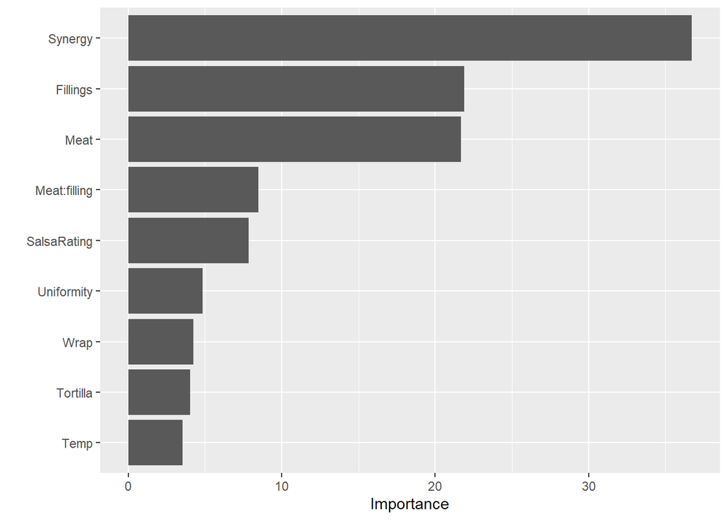

```r
fit(rand_recipe_wf, burrito_train) %>% extract_fit_engine() %>% vip()
```

Looking at the random forest we can see the importance of each predictor variable. It weird to find that Synergy seems to be the most important predictor variable for overall score of a burrito. Flavor synergy which is like the flavor combination rating.

## Ingredient Random Forest Model

```r
rand_ingred_wf %>%
     fit(burrito_train)
```

```
## == Workflow [trained] ==========================================================
## Preprocessor: Recipe
## Model: rand_forest()
##
## -- Preprocessor ----------------------------------------------------------------
## 0 Recipe Steps
##
## -- Model -----------------------------------------------------------------------
## Ranger result
##
## Call:
##  ranger::ranger(x = maybe_data_frame(x), y = y, importance = ~"impurity",      num.threads = 1, verbose = FALSE, seed = sample.int(10^5,          1))
##
## Type:                             Regression
## Number of trees:                  500
## Sample size:                      244
## Number of independent variables:  35
## Mtry:                             5
## Target node size:                 5
## Variable importance mode:         impurity
## Splitrule:                        variance
## OOB prediction error (MSE):       0.457834
## R squared (OOB):                  0.05966191
```

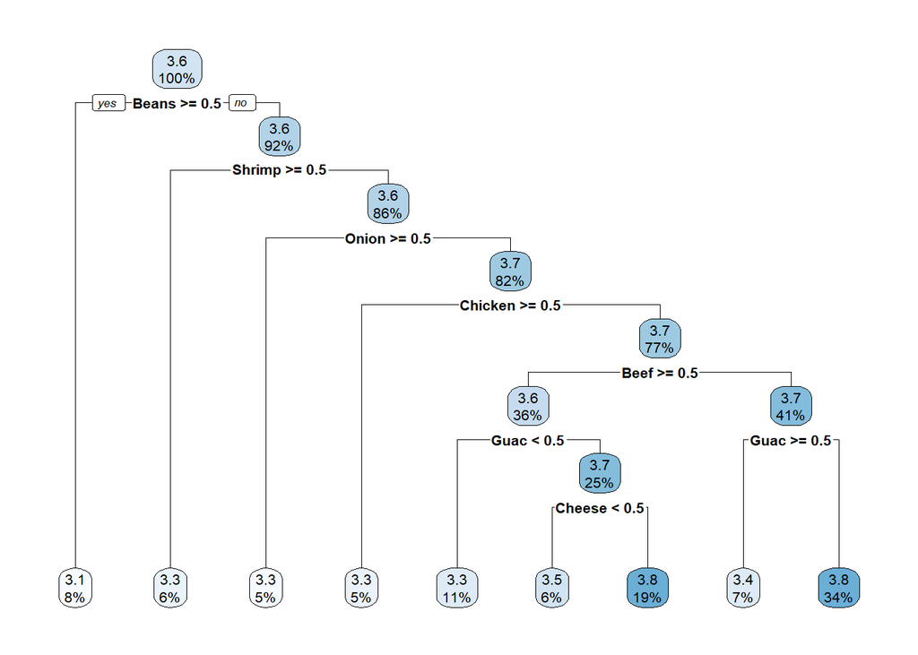

```r
ingred_tree <- decision_tree(mode = "regression") %>%
     set_engine("rpart")


plot <- ingred_tree %>% fit(overall ~ Beef + Pico + Guac + Cheese + Fries + `Sour cream` + Pork + Chicken + Shrimp + Fish + Rice +
                          Beans + Lettuce + Tomato + `Bell peper` + Carrots + Cabbage + Sauce + SalsaIngred + Cilantro +
                          Onion + Taquito + Pineapple + Ham  + `Chile relleno` + Nopales + Lobster + Queso + Egg + Mushroom +
                          Bacon + Sushi + Avocado + Corn + Zucchini,  data = burrito_train)

rpart.plot::rpart.plot(extract_fit_engine(plot), roundint = FALSE)
```

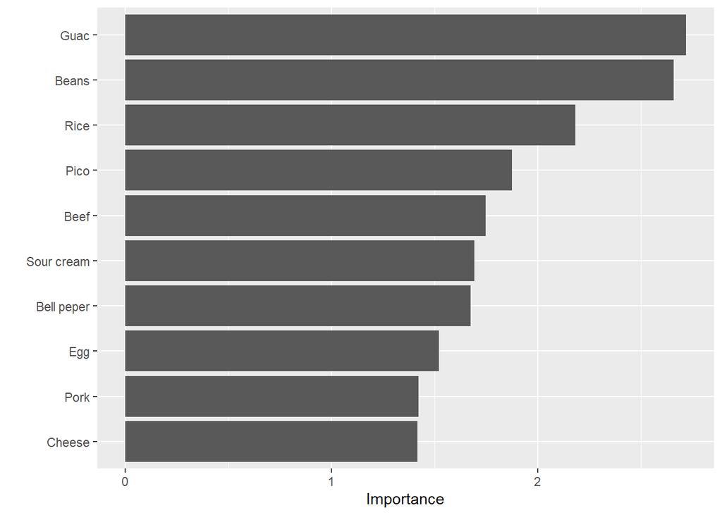

```r
fit(rand_ingred_wf, burrito_train) %>% extract_fit_engine() %>% vip()
```

## Combined Random Forest Model

```r
rand_combination_wf %>%
     fit(burrito_train)
```

```
## == Workflow [trained] ==========================================================
## Preprocessor: Recipe
## Model: rand_forest()
##
## -- Preprocessor ----------------------------------------------------------------
## 0 Recipe Steps
##
## -- Model -----------------------------------------------------------------------
## Ranger result
##
## Call:
##  ranger::ranger(x = maybe_data_frame(x), y = y, importance = ~"impurity",      num.threads = 1, verbose = FALSE, seed = sample.int(10^5,          1))
##
## Type:                             Regression
## Number of trees:                  500
## Sample size:                      244
## Number of independent variables:  14
## Mtry:                             3
## Target node size:                 5
## Variable importance mode:         impurity
## Splitrule:                        variance
## OOB prediction error (MSE):       0.1162691
## R squared (OOB):                  0.7611966
```

```r
summary(rand_combination_wf %>% fit(burrito_train) %>% extract_fit_engine())
```

```
##                           Length Class         Mode
## predictions               244    -none-        numeric
## num.trees                   1    -none-        numeric
## num.independent.variables   1    -none-        numeric
## mtry                        1    -none-        numeric
## min.node.size               1    -none-        numeric
## variable.importance        14    -none-        numeric
## prediction.error            1    -none-        numeric
## forest                      7    ranger.forest list
## splitrule                   1    -none-        character
## treetype                    1    -none-        character
## r.squared                   1    -none-        numeric
## call                        7    -none-        call
## importance.mode             1    -none-        character
## num.samples                 1    -none-        numeric
## replace                     1    -none-        logical
```

Im going to add Guac and Cheese to our combined model

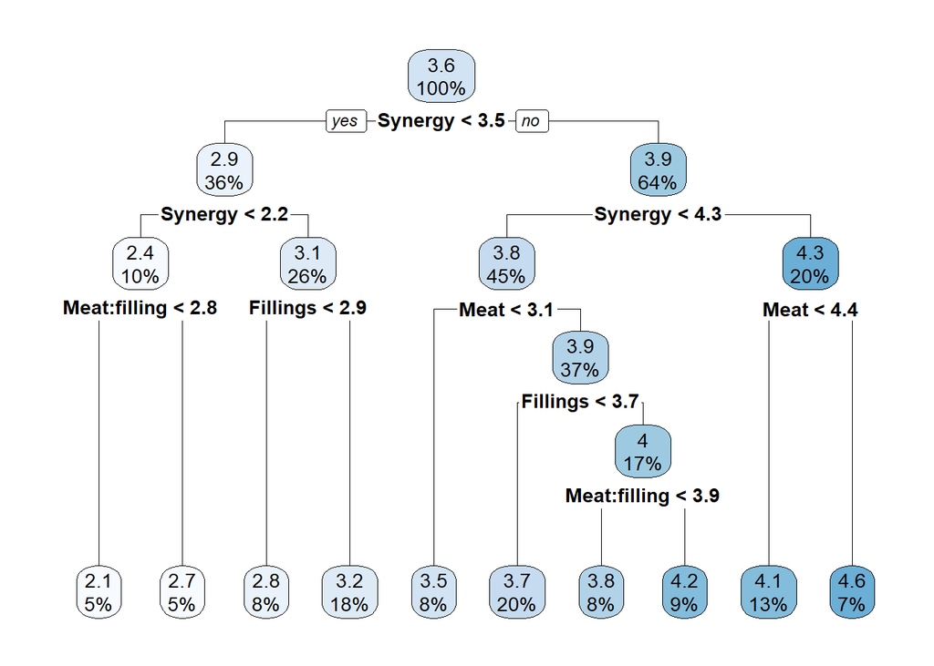

```r
combined_tree <- decision_tree(mode = "regression") %>%
     set_engine("rpart")


combinded_rec <- recipe(overall ~ Tortilla + Temp + Meat + Fillings + `Meat:filling` + Uniformity + SalsaRating + Synergy + Wrap + Beef + Pico + Pork + Chicken + Beans + Guac + Cheese, data = burrito_train)

rand_combination_tree <- workflow() %>%
     add_model(combined_tree) %>%
     add_recipe(combinded_rec)

rpart.plot::rpart.plot(extract_fit_engine(rand_combination_tree %>% fit(burrito_train)), roundint = FALSE)
```

# Testing Models

I’m going to test both the linear regression combined and the random forest regression models with cross-validation sets and tuning parameters

```r
set.seed(123)
too_many_burritos <- mc_cv(data = burrito_train, times = 10)
```

## Linear Regression Resampling

```r
combinded_rec <- recipe(overall ~ Tortilla + Temp + Meat + Fillings + `Meat:filling` + Uniformity + Synergy +
                             SalsaRating + Wrap + Beef + Pico + Pork + Chicken + Beans, data = burrito_train)

hopefully_a_better_burrito <- workflow() %>%
  add_model(burrito_reg) %>%
  add_recipe(combinded_rec)

fit_resamples(
     hopefully_a_better_burrito,
     resamples = too_many_burritos
) %>%
     collect_metrics()
```

```
## # A tibble: 2 x 6
##   .metric .estimator  mean     n std_err .config
##   <chr>   <chr>      <dbl> <int>   <dbl> <chr>
## 1 rmse    standard   0.309    10 0.00417 Preprocessor1_Model1
## 2 rsq     standard   0.803    10 0.0110  Preprocessor1_Model1
```

Looking at the combinded linear regression model it performed producing a low rmse meaning that the model is fitting the data well. We also have an r-squared value of .803. Both values show the accuracy of the burrito’s combined model. I am happy with these results for this model.

```r
combination_rand_tune <- rand_forest(mode = "regression", mtry = tune(), min_n = tune()) %>%
  set_engine("ranger", importance = "impurity")


rand_combination_tune_wf <- workflow() %>%
     add_model(combination_rand_tune) %>%
     add_recipe(combinded_rec)

tune2_grid <- grid_max_entropy(list(min_n(),
                      finalize(mtry(), burrito_train)), size = 10)

tune_grid(
  rand_combination_tune_wf,
  grid = tune2_grid,
  resamples = too_many_burritos
) -> tuned_results
```

[output not shown]

[output not shown]

[output not shown]

[output not shown]

[output not shown]

[output not shown]

[output not shown]

[output not shown]

[output not shown]

[output not shown]

[output not shown]

[output not shown]

[output not shown]

[output not shown]

[output not shown]

[output not shown]

[output not shown]

[output not shown]

[output not shown]

[output not shown]

[output not shown]

[output not shown]

[output not shown]

[output not shown]

[output not shown]

[output not shown]

[output not shown]

[output not shown]

[output not shown]

[output not shown]

[output not shown]

[output not shown]

[output not shown]

[output not shown]

[output not shown]

[output not shown]

[output not shown]

[output not shown]

[output not shown]

[output not shown]

[output not shown]

[output not shown]

[output not shown]

[output not shown]

[output not shown]

[output not shown]

[output not shown]

[output not shown]

[output not shown]

[output not shown]

[output not shown]

[output not shown]

[output not shown]

[output not shown]

[output not shown]

[output not shown]

[output not shown]

[output not shown]

[output not shown]

[output not shown]

[output not shown]

[output not shown]

[output not shown]

[output not shown]

[output not shown]

[output not shown]

[output not shown]

[output not shown]

[output not shown]

[output not shown]

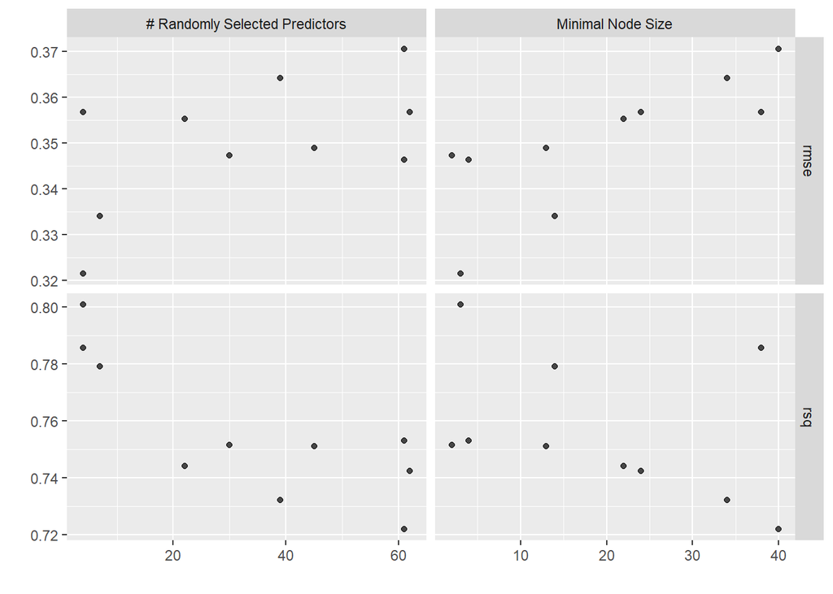

```r
tuned_results %>%
     autoplot()
```

```r
show_best(tuned_results, metric = "rmse")
```

```
## # A tibble: 5 x 8
##    mtry min_n .metric .estimator  mean     n std_err .config
##   <int> <int> <chr>   <chr>      <dbl> <int>   <dbl> <chr>
## 1     4     3 rmse    standard   0.322    10 0.00608 Preprocessor1_Model02
## 2     7    14 rmse    standard   0.334    10 0.00511 Preprocessor1_Model04
## 3    61     4 rmse    standard   0.346    10 0.00545 Preprocessor1_Model09
## 4    30     2 rmse    standard   0.347    10 0.00521 Preprocessor1_Model08
## 5    45    13 rmse    standard   0.349    10 0.00584 Preprocessor1_Model01
```

# Testing

I know you said to pick one model but I was just way too curious and I wanted to see what model did better on the testing set.

## Linear Regression

```r
hopefully_a_better_burrito %>%
     last_fit(
          whats_your_order
     ) %>% collect_metrics()
```

```
## # A tibble: 2 x 4
##   .metric .estimator .estimate .config
##   <chr>   <chr>          <dbl> <chr>
## 1 rmse    standard       0.350 Preprocessor1_Model1
## 2 rsq     standard       0.805 Preprocessor1_Model1
```

## Random Forest

```r
finalize_workflow(
     rand_combination_tune_wf,
     tibble(min_n = c(4), mtry = c(4))
) %>%
     last_fit(
          whats_your_order
     ) %>% collect_metrics()
```

```
## # A tibble: 2 x 4
##   .metric .estimator .estimate .config
##   <chr>   <chr>          <dbl> <chr>
## 1 rmse    standard       0.397 Preprocessor1_Model1
## 2 rsq     standard       0.772 Preprocessor1_Model1
```

## Results

Looking at the results both models would be entirely suitable to predict the overall score of a burrito based off the predictors. However, I would probably choose to use our linear regression model since it produced a lower rmse value and a higher rsq value, but also because a linear regression model has the easier to interrupt.

```r
summary(hopefully_a_better_burrito %>% fit(leftovers) %>% extract_fit_engine())
```

```
##
## Call:
## stats::lm(formula = ..y ~ ., data = data)
##
## Residuals:
##     Min      1Q  Median      3Q     Max
## -1.0947 -0.1590  0.0002  0.1764  0.6426
##
## Coefficients:
##                Estimate Std. Error t value Pr(>|t|)
## (Intercept)    -0.57185    0.31466  -1.817   0.0736 .
## Tortilla        0.03279    0.05559   0.590   0.5573
## Temp            0.13558    0.04334   3.128   0.0026 **
## Meat            0.34596    0.06170   5.607 4.22e-07 ***
## Fillings        0.17736    0.07463   2.377   0.0203 *
## `Meat:filling`  0.04792    0.05940   0.807   0.4227
## Uniformity      0.06265    0.04640   1.350   0.1815
## Synergy         0.33146    0.07899   4.196 8.17e-05 ***
## SalsaRating    -0.04703    0.05227  -0.900   0.3715
## Wrap            0.08891    0.04673   1.902   0.0614 .
## Beef            0.01640    0.13264   0.124   0.9019
## Pico           -0.18651    0.11377  -1.639   0.1058
## Pork            0.18945    0.20137   0.941   0.3502
## Chicken        -0.27705    0.18654  -1.485   0.1422
## Beans          -0.35664    0.22801  -1.564   0.1225
## ---
## Signif. codes:  0 '***' 0.001 '**' 0.01 '*' 0.05 '.' 0.1 ' ' 1
##
## Residual standard error: 0.3397 on 67 degrees of freedom
## Multiple R-squared:  0.8445, Adjusted R-squared:  0.812
## F-statistic: 25.99 on 14 and 67 DF,  p-value: < 2.2e-16
```

# Conclusion